# Data Science Capstone: MileStone

Andrew Abisha Hu

8/21/2018

## Introduction

The goal here is to build your first simple model for the relationship between words. This is the first step in building a predictive text mining application. You will explore simple models and discover more complicated modeling techniques.

### Task to accomplish

1. Build basic n-gram model - using the exploratory analysis you performed, build a basic n-gram model for predicting the next word based on the previous 1, 2, or 3 words.
2. Build a model to handle unseen n-grams - in some cases people will want to type a combination of words that does not appear in the corpora. Build a model to handle cases where a particular n-gram isn’t observed.

Does the link lead to an HTML page describing the exploratory analysis of the training data set?

Has the data scientist done basic summaries of the three files? Word counts, line counts and basic data tables?

Has the data scientist made basic plots, such as histograms to illustrate features of the data?

Was the report written in a brief, concise style, in a way that a non-data scientist manager could appreciate?

## Executive Summary

The objective of this milestone report is to explain the process of building the n-grams model in order to create a Natural Language Processing (NLP) App and present a basic exploratory analysis of the data set.

I use the file that contains “English” language only, sources from blog, twitter and news. Because the original data file is too huge, I sample them with 25000 rows in each source (Twitter, Blog and News), and then combine them altogether to a file called “sample” (with total 75000 observations)

After create the sample file, I start cleaning the data, removing the unwanted symbols. Getting the data prepared, I run the sample data through the “Work Flow”. That is: Corpus, Tokenization and create a Document Frequency Matrix (DFM).

Finally, I did a exploratory analysis using the dfm just created, providing top 20 features in each dfm with ggplot.

Note: I use the “quanteda” package instead of the classic text mining “tm” package becuase quanteda is simply more efficient.

## Data Processing

### Loading libraries

```r
suppressWarnings(library(stringi))
#suppressWarnings(library(NLP))
suppressWarnings(library(ggplot2))
suppressWarnings(library(quanteda))
suppressWarnings(library(dplyr))
suppressWarnings(library(data.table))
```

### Reading the data:

```r
#Set work directory
setwd("/users/andrewhu/desktop/final/en_US")
#Read text file
enblogrul <- file("en_US.blogs.txt", open="rb")
entwurl <- file("en_US.twitter.txt", open="rb")
enneurl <- file("en_US.news.txt", open="rb")

#Read in the lines
en_blogs<- readLines(enblogrul, encoding = "UTF-8", skipNul=TRUE)

en_tw<- readLines(entwurl, encoding = "UTF-8", skipNul=TRUE)

en_news<- readLines(enneurl, encoding = "UTF-8", skipNul=TRUE)
```

### Summaries of three files:

```r
# legnth of Lines for each file
length(en_blogs)
```

```
## [1] 899288
```

```r
length(en_tw)
```

```
## [1] 2360148
```

```r
length(en_news)
```

```
## [1] 1010242
```

```r
# Numbers of words for each file
sum(stri_count_words(en_blogs))
```

```
## [1] 37546239
```

```r
sum(stri_count_words(en_news))
```

```
## [1] 34762395
```

```r
sum(stri_count_words(en_news))
```

[output not shown]

```
## [1] 34762395
```

```r
# max characters  for each file
max(nchar(en_blogs))
```

```
## [1] 40833
```

```r
max(nchar(en_tw))
```

```
## [1] 140
```

```r
max(nchar(en_news))
```

```
## [1] 11384
```

### Sampling the data

Simply sample each file of n rows, and then combine them.

```r
set.seed(525)
mini_tw <- sample(en_tw, size = 25000, replace = F)
mini_blogs <- sample(en_blogs, size = 25000, replace = F)
mini_news <- sample(en_news, size = 25000, replace = F)

sample <- c(mini_tw,mini_blogs,mini_news)
```

### Cleaning data

```r
# filter weird symbols
sample <- gsub("[^[:alpha:][:space:]']", " ", sample)
sample <- gsub("ã", "'", sample)
sample <- gsub("ð", "'", sample)

sample <- gsub(" #\\S*","", sample) #delete hastag
sample <- gsub("(f|ht)(tp)(s?)(://)(\\S*)", "", sample) # delete http links
sample <- gsub("[^0-9A-Za-z///' ]", "", sample) #delete special chars

#check the length for our sample
length(sample)
```

```
## [1] 75000
```

## Work flow:

### Corpus:

**Purpose:**

```
 1. Save character strings and variables in a data frame

 2. Combine texts with document-level variables
```

```r
#corpus for the whole sample
corp <- corpus(sample)
```

### Tokens:

**Purpose:**

```
Stores tokens in a list of vectors
```

```r
#tokenization for the corpus
toks <- tokens(corp)

#generate ngrams for 1~3
unigram <- tokens_ngrams(toks, n=1)
bigram <- tokens_ngrams(toks, n=2)
trigram <- tokens_ngrams(toks, n=3)
```

### Document feature matrix (DFM)

**Purpose:**

```
Represents frequencies of features in documents in a matrix
```

```r
#document frequency matrix for ngram 1~4
unigram_dfm <- dfm(unigram, what="fasterword", ngrams=1)

bigram_dfm <- dfm(bigram, what="fasterword", ngrams=2)

trigram_dfm <- dfm(trigram, what="fasterword", ngrams=3)
```

## Exploratory Analysis:

After processing the data, we can start creating top features for each n grams, subsetting them into different data frame and then plotting them to see the frequencies.

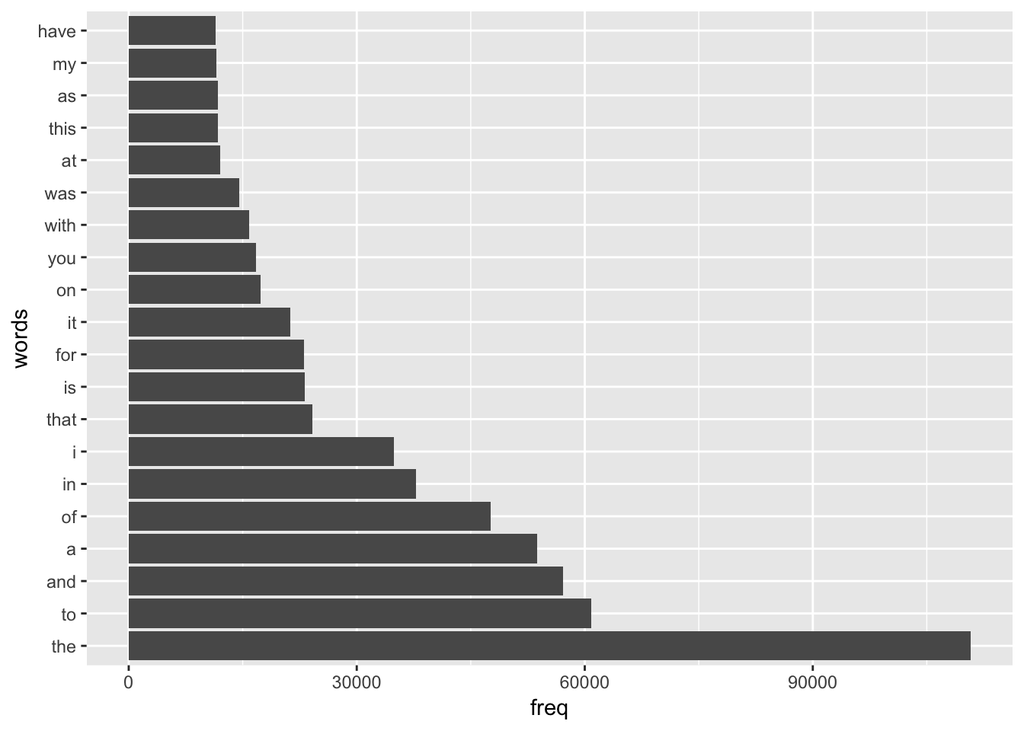

```r
#Create top features for each n gram
top20_n1<- topfeatures(unigram_dfm,20)
top20_n2<- topfeatures(bigram_dfm ,20)
top20_n3<- topfeatures(trigram_dfm,20)


#create data frame
top20_df_n1 <- data.frame(word=names(top20_n1), freq=top20_n1,row.names = NULL)
top20_df_n2 <- data.frame(word=names(top20_n2), freq=top20_n2,row.names = NULL)
top20_df_n3 <- data.frame(word=names(top20_n3), freq=top20_n3,row.names = NULL)


#Bar chart for ngram:1, top 20 features
g <- ggplot(top20_df_n1[1:20,], aes(reorder(word,-freq),freq))
g + geom_bar(stat="identity") + labs(x= "words", y= "freq")+coord_flip()
```

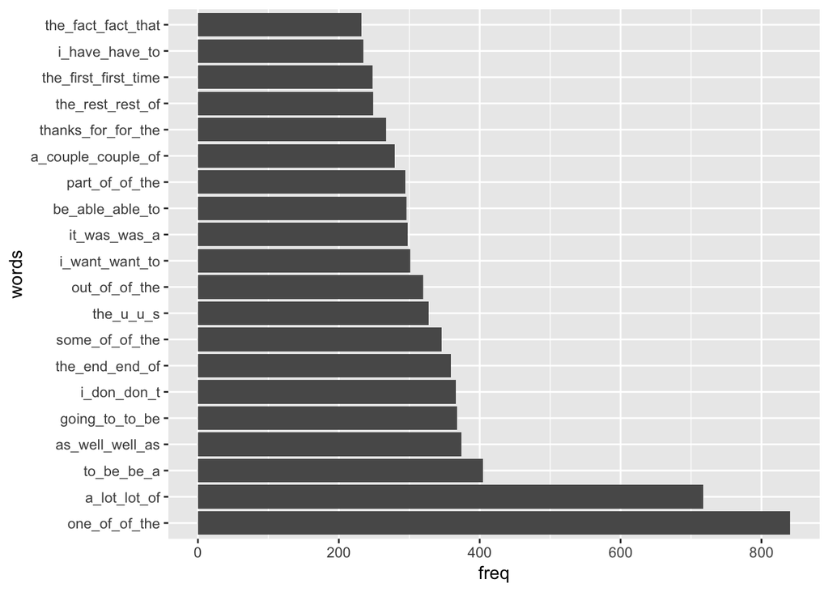

```r
#Bar chart for ngram:2, top 20 features
g <- ggplot(top20_df_n2[1:20,], aes(reorder(word,-freq),freq))
g + geom_bar(stat="identity")+ labs(x= "words", y= "freq")+coord_flip()
```

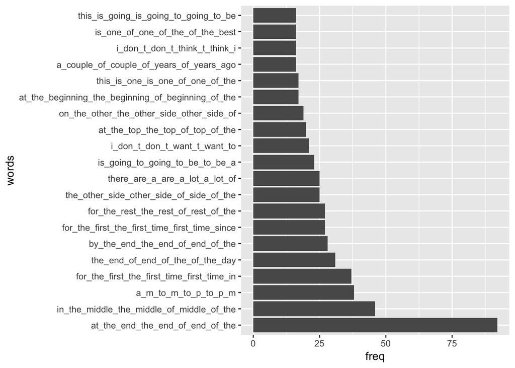

```r
#Bar chart for ngram:3, top 20 features
g <- ggplot(top20_df_n3[1:20,], aes(reorder(word,-freq),freq))
g + geom_bar(stat="identity") + labs(x= "words", y= "freq")+coord_flip()
```

## Interesting Findings:

1. In the unigram, prepositions, such as “to” “a” “of” appear frequent. The most frequent word is “the”.
2. In the bigram, prepositions phrases or conjunctions are the most frequent. Such as “one of”“,”a lot“,”as well“,”some of"
3. In the trigram, things related to positions, like “first”“,”middle“” and “end” appears a lot. For example, the most frequent one is “at the end”, “the end of”, “end of the”. The second one is “in the middle”, “the middle of”, “middle of the”. Also , “by the end”, “for the first” are also among top 10.

## Next Step:

Next, I will use Kneser-Kney Smoothing to calculate the probability based on a given conditon of what specific word appear at what position. And then I will create a function to predict the 3rd word given first 2 words, and predict the 2nd word given the first word.